# Análise de dados longitudinais (Parte 2): O pacote lavaan para equações estruturais

Abril, 2022

## Etapas na Modelação de Equações Estruturais

1. Especificação  
   *Que modelo queremos investigar? Preditores? Outcomes? Relações entre variáveis?*
2. Identificação  
   *Será possível estimar o modelo?*
3. Estimação  
   *Como podemos obter a melhor estimativa dos parâmetros do modelo?*
4. Avaliação  
   *Em que medida o modelo representa corretamente os dados observados?*
5. Re-especificação  
   *Será possível melhorar o nosso modelo? Que modificações são necessárias?*
6. Interpretação  
   *Quais efeitos são significativos? Serão esses efeitos relevantes?*

## O pacote lavaan para modelação de equações estruturais no R

- Software de distribuição livre, não comercial
- Desenvolvido por Yves Rosseel, Department of Data Analysis, Ghent University
- **Suporta um extenso número de procedimentos utilizados em SEM:**
  - Análise Fatorial Confirmatória - CFA()
  - Modelação de Equações Estruturais - SEM()
  - Modelação geral de estruturas de médias e covariâncias - lavaan()
  - Permite modelar variáveis contínuas, dicotómicas ou ordinais

## Instalação e documentação de apoio

- Existem 3 tipos de comandos na utilização geral do lavaan:
  - Especificação de modelos
  - Estimação de modelos
  - Extração de resultados

```r
install.packages("lavaan")
library(lavaan)
help(package="lavaan")
website do lavaan: browseURL("http://lavaan.org")
```

## AGENDA

### O pacote lavaan para equações estruturais:

- **Especificação de modelos**
- **Estimação de modelos**
- **Avaliação de resultados**
- **Exemplo: Modelos de pistas**

## Especificação de modelos

## Diagramas de pistas

- A especificação de modelos é frequentemente feita com recurso a **diagramas**
  - Representações gráficas dos modelos;
  - Os diagramas podem incluir 5 tipos de formas:

> **Retângulos** (ou quadrados) -> variáveis observadas (VO)  
> **Círculos** -> variáveis latentes (VL)  
> **Setas unidirecionais** -> coeficientes de regressão  
> **Setas bi-direcionais** -> variâncias ou covariâncias  
> **Triângulos** -> constantes (1) para médias ou intercepts

## Diagramas de pistas

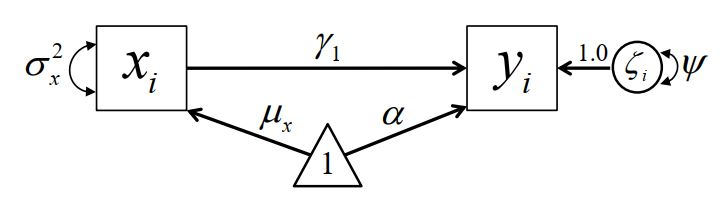

Correspondência direta com a equação de regressão:

\[y_{i}= \alpha + \gamma_{1}x_{1i} + \zeta_{i} ~~~~~~~~~~~~~~~~~~~~ \zeta_{i} \sim N(0,\Psi)\] \(\alpha\) *(alfa)* = intercept de y  
\(\gamma\) *(gama)* = coeficiente de regressão  
\(\zeta\) *(zeta)* = resíduo

## Diagramas de pistas

Dependendo das fontes, poderão encontrar-se algumas variações deste tipo de diagramas

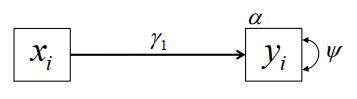

- Existem aplicações que permitem especificar modelos com recurso a diagramas:
  - Amos
  - [Onyx](http://onyx.brandmaier.de/)

## Fórmula do modelo

- Linguagem que descrever o modelo (ver parte 1)
  - Exemplo: y ~ x + z
- Um modelo no lavaan é constituido por um sistema de fórmulas de equações

```r
meu_model <- "y ~ x + m
              m ~ x"
```

- Cada linha de um modelo é uma fórmula com 3 partes:
  - “left-hand side” (lhs);
  - “operator” (op);
  - “right-hand side” (rhs).

*Exemplo:* **y (lhs) ~ (op) x + z (rhs)**

## Operadores e modificadores

| Tipo | Operador | Exemplo |
| --- | --- | --- |
| variável latente | =~ | x =~ x1 + x2 (x é medido por x1 e x2) |
| regressão | ~ | y ~ x (regressão de y em x) |
| (co)variância | ~~ | x ~~ y (correlação entre x e y) |
| intercept | ~1 | x~1 (representa o intercept de x) |
| escala | * | x =~ 1*x1 + 1*x2 (usado para fixar parâmetros) |
| definir par. | := | y ~ c*x + b*m; m ~ a*x; ind := a*c (usado para especificar parâmetros) |
| igualar par. | == | x =~ a*x1 + b*x2; a==b (usado para impor igualdade entre parâmetros |

## Operadores e modificadores

- Elementos no rhs podem ser precedidos de **modificadores**
  - Servem geralmente para libertar ou fixar parâmetros

```r
meu_modelo <- "
          # Variáveis latentes
          x =~ NA*x1 + x2 + x3
          y =~ NA*y1 + y2 + y3
          z =~ NA*z1 + z2 + z3
          # variâncias das variáveis latentes
          x ~~ 1*x
          y ~~ 1*y
          z ~~ 1*z
          "
```

## Operadores e modificadores

- … ou para impor condições

```r
meu_modelo <- "
          x =~ L1.1*x1 + L1.2*x2 + L1.3*x3
          y =~ L2.1*y1 + L2.2*y2 + L2.3*y3
          z =~ L3.1*z1 + L3.2*z2 + L3.3*z3
          # Condições
          L1.1 == L2.1
          L1.2 == L2.2
          L1.3 == L2.3
          L3.1 == (L3.2 + L3.3)^2
          "
```

## Estimação de modelos

## A função **lavaan()**

- **lavaan()** é a função base para ajustar um modelo:
  - Esta função não tem argumento por defeito
  - Será necessário que o utilizador identifique o modelo

```r
library(lavaan)
```

```r
args("lavaan")
```

```
## function (model = NULL, data = NULL, ordered = NULL, sampling.weights = NULL,
##     sample.cov = NULL, sample.mean = NULL, sample.th = NULL,
##     sample.nobs = NULL, group = NULL, cluster = NULL, constraints = "",
##     WLS.V = NULL, NACOV = NULL, slotOptions = NULL, slotParTable = NULL,
##     slotSampleStats = NULL, slotData = NULL, slotModel = NULL,
##     slotCache = NULL, sloth1 = NULL, ...)
## NULL
```

## A função **lavaan()**

Vários argumentos da função **lavaan()** podem ser utilizados para automaticamente fixar parâmetros e identificar os modelos

```r
meu_modelo <- "
          # Variáveis latentes
          x =~ L1.1*x1 + L1.2*x2 + L1.3*x3
          y =~ L2.1*y1 + L2.2*y2 + L2.3*y3
          z =~ L3.1*z1 + L3.2*z2 + L3.3*z3
          # Correlações entre fatores
          x ~~ y + z
          y ~~ z
          "
fit <- lavaan(meu_modelo, data = meus_dados, # nome do modelo e dados
              auto.fix.first = TRUE,  # fixa a 1.0 o primeiro loading de cada latente
              auto.var = TRUE) # estima variâncias e residuais
```

```r
?lavOptions # ver a lista de argumentos
```

## As funções **cfa()** e **sem()**

- Funções de segunda ordem para ajustar modelos: **cfa()** e **sem()**
- cfa() e sem() definem um conjunto de opções por defeito, nomeadamente:
  - **auto.var = TRUE** (estima variâncias);
  - **auto.cov.lv.x = TRUE** (estima covariâncias entre variáveis exógenas);
  - **auto.fix.first = TRUE** (fixa primeiro loading a 1.0).

```r
?cfa
?sem
?lavOptions
lavOptions() # default options used by the lavaan() function
```

## Avaliação de resultados

## Funções para extrair resultados

- Existem várias funções que permitem extrair diferentes tipos de resultados
- Algumas das mais utilizadas são:
  - **summary(fit)** (apresenta sumário dos resultados)
  - **lavInspect(fit)** (apresenta uma lista das matrizes dos modelos e dos parâmetros livres e estimados)
  - **predict(fit)** (calcula os scores fatoriais)
  - **parameterEstimates(fit)** (apresenta as estimativas dos parâmetros)
  - **fitMeasures(fit)** (apresenta medidas de ajustamento)
  - **modindice(fit)** (apresenta índices de modificação)

## Funções para extrair resultados

- Alguns argumentos podem completar os resultados base da função **summary()**

```r
meu_modelo <- "
          # Variáveis latentes
          x =~ L1.1*x1 + L1.2*x2 + L1.3*x3
          y =~ L2.1*y1 + L2.2*y2 + L2.3*y3
          # Correlações entre fatores
          x ~~ y
          "
fit <- lavaan(meu_modelo, data = meus_dados, # nome do modelo e dados
              auto.fix.first = TRUE,  # fixa a 1.0 o primeiro loading de cada latente
              auto.var = TRUE) # estima variâncias e variâncias residuais

summary(fit, standardized=TRUE, rsq=TRUE, fit.measures=TRUE, modindices=TRUE)
# sumário mais completo
```

## Exemplo: Modelos de pistas

## Configurações iniciais

### Preparação de pacotes

- Para reproduzir os seguintes exemplos será necessário carregar 3 pacotes:

```r
library(lavaan)
library(semTools)
library(semPlot)
```

[lavaan website](https://lavaan.ugent.be/)  
[semTools website](https://www.rdocumentation.org/packages/semTools/versions/0.5-4)  
[semPlot website](http://sachaepskamp.com/semPlot/examples)

## Importação de dados

- **Iremos utilizar uma base de dados construída a partir dos dados descritivos de:**
  - Roth, D. L., Wiebe, D. J., Fillingim, R. B., & Shay, K. A. (1989). Life events, fitness, hardiness, and health: A simultaneous analysis of proposed stress-resistance effects. *Journal of Personality and Social Psychology, 57*(1), 136–142. https://doi.org/10.1037/0022-3514.57.1.136
- Podemos importar esta base de dados para o R através do seguinte código:

```r
DF_roth <-
  read.csv(
    "G:\\My Drive\\FPCEUP\\R trainning\\GitRepo\\Intro to Lavaan\\Intro_to_Lavaan\\Intro to Lavaan_DATA\\DF_roth.csv")
```

- Physical illness (*illness*); Exercise participation (*exercise*); Perceived fitness (*fitness*); Dispositional hardiness (*hardy*); Stressful life experience (*stress*).

## Importação de dados

- Esta base de dados é utilizada por Rex Kline no seu livro dedicado à modelação de equações estruturais

[figure not shown]

## Alguma estatística descritiva

### Características gerais da base de dados

```r
dim(DF_roth)
```

```
## [1] 373   5
```

```r
names(DF_roth)
```

```
## [1] "exercise" "hardy"    "fitness"  "stress"   "illness"
```

```r
head(DF_roth,4)
```

```
##    exercise     hardy   fitness     stress  illness
## 1  97.58960 -0.243680  84.47890 -35.537440 796.8197
## 2  66.65038  2.783052  99.26339 -49.774773 625.6883
## 3 162.71042 44.812489  77.80067  -2.816133 735.6340
## 4  86.11467 15.079458 130.17116  78.125718 774.0359
```

## Alguma estatística descritiva (cont.)

### Sumário

```r
summary(DF_roth)
```

```
##     exercise            hardy             fitness           stress
##  Min.   :-131.705   Min.   :-131.062   Min.   :-46.47   Min.   :-188.720
##  1st Qu.:  -6.544   1st Qu.: -24.194   1st Qu.: 42.28   1st Qu.: -41.003
##  Median :  44.308   Median :   2.154   Median : 68.18   Median :   4.749
##  Mean   :  40.900   Mean   :   0.000   Mean   : 67.10   Mean   :   4.800
##  3rd Qu.:  81.163   3rd Qu.:  22.470   3rd Qu.: 90.05   3rd Qu.:  51.436
##  Max.   : 257.746   Max.   : 160.870   Max.   :174.68   Max.   : 195.264
##     illness
##  Min.   :554.8
##  1st Qu.:674.2
##  Median :718.6
##  Mean   :716.7
##  3rd Qu.:759.7
##  Max.   :922.4
```

## Alguma estatística descritiva (cont.)

### Correlações

```r
cor(DF_roth)
```

```
##          exercise hardy fitness stress illness
## exercise     1.00 -0.03    0.39  -0.05   -0.08
## hardy       -0.03  1.00    0.07  -0.23   -0.16
## fitness      0.39  0.07    1.00  -0.13   -0.29
## stress      -0.05 -0.23   -0.13   1.00    0.34
## illness     -0.08 -0.16   -0.29   0.34    1.00
```

## Alguma estatística descritiva (cont.)

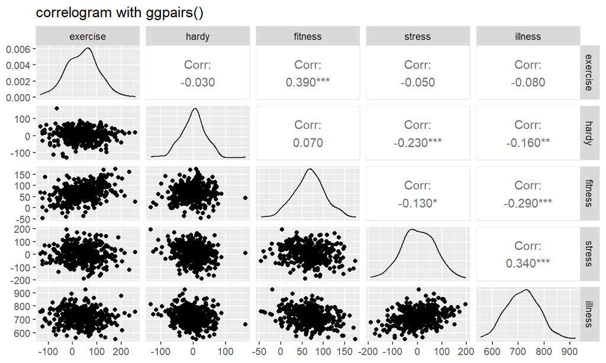

```r
ggpairs(DF_roth, title="correlogram with ggpairs()")
```

## Regressão linear simples

### Efeito da prática de exercício na incidência de problemas de saúde

- A expressão geral do modelo de regressão linear é:

\[\hat{Y_{i}} = \beta_0 + \beta_1X_{i1} + \beta_2X_{i2} + ... + \beta_pX_{ip}\]

\[{Y_{i}} = \beta_0 + \beta_1X_{i1} + \beta_2X_{i2} + ... + \beta_pX_{ip} + \varepsilon_{i}\]

Onde… \[\varepsilon_{i} = {Y_{i}} - \hat{Y_{i}}\]

## Regressão linear simples

### A expressão anterior aplicada às nossas variáveis toma a seguinte forma:

\[\hat{Iillness_{i}} = \beta_0 + \beta_1Exercise_{i}\]  
Onde:

\(\hat{Iillness_{i}}\) = score de *illness* estimado  
\(Exercise_{i}\) = score de *exercise*  
\(\beta_0\) = valor de **illness** quando **exercise** assume o valor zero  
\(\beta_1\) = coeficiente de regressão (i.e., a mudança esperada em *illness* em **função** de *exercise*)

## Estimação OLS do modelo

- Um modelo de regressão pode ser testado no R com o método OLS usando a função **lm()**

```r
lm_fit.1 <- lm(illness ~ exercise, data = DF_roth)
round(summary(lm_fit.1)$coefficients, 2) # mostrar parametros
```

```
##             Estimate Std. Error t value Pr(>|t|)
## (Intercept)   719.77       3.79  189.80     0.00
## exercise       -0.08       0.05   -1.55     0.12
```

- Os resultados sugerem um efeito não significativo de *exercise* sobre *ilness*

## Regressão linear simples no lavaan (Especificação)

Testamos agora o mesmo modelo no lavaan  
- O objeto “model.1” define a fórmula do modelo

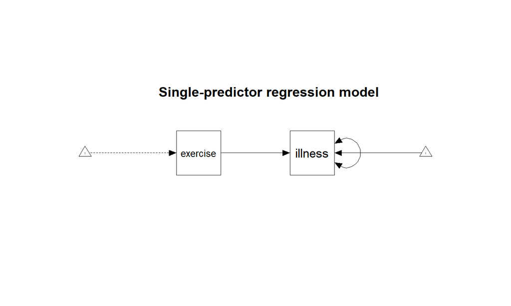

```r
model.1 <- "
illness ~ exercise" # illness em função de exercise
```

## Regressão linear simples no lavaan (Estimação)

Estimamos este modelo no lavaan usando a função *sem()*  
- atribuir o resultado ao objeto *fit.1*

```r
fit.1 <- sem(model.1, data=DF_roth, meanstructure=T)
```

*Nota: Incluímos o argumento “meanstructure” para que o intercept da regressão seja estimado*

## Estimação por Máxima Verossimilhança (ML)

Estimação - processo pelo qual são estimados parâmetros a partir da amostra

Propriedades de um bom estimador:

- **Centrado ou não enviesado** - a média das estimativas obtidas para todas as amostras possíveis tende para o valor da população;
- **Consistente** - à medida que aumenta a dimensão da amostra, a variabilidade da sua distribuição diminui;
- **Eficiente** - não enviesado e com menor variância do que qualquer outro estimador não enviesado

**O ML é o estimador mais usado em SEM**:  
- Permite uma estimativa centrada e consistente dos parâmetros

## Estimação por Máxima Verossimilhança (ML)

O ML responde à seguinte pergunta:

- *Quais os parâmetros que maximizam a probabilidade de observarmos os dados que efetivamente observamos?*
- Momentos populacionais e implícitos ao modelo  
  \(\Sigma\) e \(\Sigma(\theta)\) = variâncias e covariâncias  
  \(\nu\) e \(\nu(\theta)\) = médias
- Momentos amostrais e implícitos ao modelo  
  \(S\) e \(\Sigma(\hat{\theta})\) = variâncias e covariâncias  
  \(m\) e \(\nu(\hat{\theta})\) = médias

Os momentos amostrais são realizações dos momentos populacionais (desconhecidos)

## Estimação por Máxima verossimilhança (ML)

Para um conjunto de variáveis aleatórias existe uma matriz de variâncias e covariâncias e uma matriz de médias

\[\tiny S = \begin{bmatrix} S^2_y \\ S_{x_{1}y} & S^2_{x_{1}} \\ S_{x_{2}y} & S_{x_{2}x_{1}} & S^2_{x_{2}} \\ ... & ... & ... & ... \\ S_{x_{q}y} & S_{x_{q}x_{1}} & S_{x_{q}x_{2}} & S^2_{x_{q}} \end{bmatrix}\]

\[\tiny m = \begin{bmatrix} \bar{y} \\ \bar{x_1} \\ \bar{x_2} \\ ... \\ \bar{x_q} \end{bmatrix}\] \(S\) e \(m\) são estimativas da população, calculadas pelas fórmulas habituais

## Estimação por Máxima verossimilhança (ML)

Subacente a \(\Sigma\) e \(\nu\) estão um conjunto de parâmetros (\(\theta\), parâmetros implícitos ao modelo)

O ML permite uma estimava para (\(\theta\)) com base em \(S\) e \(m\):

\[\scriptsize \hat{\theta}^T = [\hat{\alpha}, \hat{\gamma_{1}}, \hat{\gamma_{2}}, ..., \hat{\gamma_{q}}, \hat{\psi}]\] Por sua vez, \(\hat{\theta}\) permite calcular \(\Sigma(\hat{\theta})\) e \(\nu(\hat{\theta})\) (Momentos implícitos ao modelo)

- O melhor modelo é aquele que minimiza as diferenças entre \(S\) e \(\Sigma(\hat{\theta})\) e entre \(m\) e \(\nu(\hat{\theta})\)

\(min(S - \Sigma(\hat{\theta}))\)  
\(min(m - \nu(\hat{\theta}))\)

- **Notar semelhanças com OLS: \(min(y_i - \hat{y}_i)\)**

## Estimação por Máxima verossimilhança (ML)

### [Passos na estimação ML](https://www.youtube.com/watch?v=XepXtl9YKwc&ab_channel=StatQuestwithJoshStarmer)

1. São criados valores iniciais para os parametros a estimar (\(\hat{\theta}\)) (*start values*)
2. A função ML calcula a probabilidade de se observar \(S\) e \(m\) dado \(\hat{\theta}\) estabelecido no passo 1 (*1.ª iteração*)
3. É atualizado \(\hat{\theta}\) e repetem-se os passos 1 e 2 até que não existam diferenças entre duas probablilidas sucessivas (*atingida convergência*)
4. As estatísticas de ajustamento, médias e erros padrão dos parâmetros são calculados para o modelo cuja verosimilhança é máxima.

## Regressão linear simples no lavaan (Avaliação)

A função *summary()* extrai os resultados da estimação do modelo

```r
summary(fit.1, standardized = TRUE, rsquare = TRUE)
```

```r
parameterEstimates(fit.1, rsquare = TRUE)
```

```
##        lhs op      rhs      est      se       z pvalue ci.lower ci.upper
## 1  illness  ~ exercise   -0.075   0.048  -1.550  0.121   -0.170    0.020
## 2  illness ~~  illness 3868.368 283.262  13.657  0.000 3313.184 4423.551
## 3 exercise ~~ exercise 4410.394   0.000      NA     NA 4410.394 4410.394
## 4  illness ~1           719.774   3.782 190.309  0.000  712.361  727.187
## 5 exercise ~1            40.900   0.000      NA     NA   40.900   40.900
## 6  illness r2  illness    0.006      NA      NA     NA       NA       NA
```

*Os resultados diferem ligeiramente dos resultados obtidos com a função lm() uma vez que agora estamos a utilizar um estimador diferente, o maximum likelihood (ML)*

## Modelo de regressão múltipla

- Expandimos agora o modelo anterior para incluir, também “hardy”, “fitness” e “stress” como preditores de “illness.”

\[\hat{Iillness_{i}} = \beta_0 + \beta_1Exercise_{i} + \beta_2hardy_{i} + \beta_3fitness_{i} + \beta_4stress_{i}\]  
Onde:  
\({Illness_{i}}\) = score de *illness*  
\(Exercise_{i}\) = score de *exercise*  
\(hardy_{i}\) = score de *hardy*  
\(fitness_{i}\) = score de *fitness*  
\(stress_{i}\) = score de *stress*  
\(\beta_0\) = valor de **illness** quando **exercise** assume o valor zero  
\(\beta_1\), \(\beta_2\), \(\beta_3\) & \(\beta_4\) = coeficientes de regressão para X1, X2, X3 e X4

## Estimação OLS do modelo

```r
lm_fit.2 <- lm(formula = illness ~ exercise + hardy + fitness + stress, data = DF_roth)
```

```r
summary(lm_fit.2)
```

```r
summary(lm_fit.2)$coefficients # mostrar parâmetros
```

```
##                 Estimate Std. Error     t value      Pr(>|t|)
## (Intercept) 743.74194126 6.19749418 120.0068802 3.767421e-297
## exercise      0.03176181 0.04816102   0.6594922  5.099923e-01
## hardy        -0.12145922 0.07981478  -1.5217635  1.289271e-01
## fitness      -0.44177353 0.08766096  -5.0395701  7.331144e-07
## stress        0.27125089 0.04545484   5.9674814  5.667186e-09
```

**NOTA: É implicitamente assumido que preditores são independentes.**

- Os parâmetros \(\beta_1\), \(\beta_2\), \(\beta_3\) & \(\beta_4\) são interpretados respetivamente como os efeitos médios de *exercise*, *hardy*, *fitness* e *stress* sobre *illness*, mantendo constantes os restantes preditores. \(\beta_0\) representa o valor esperado de illness quando todos os preditores assumem o valor de zero.

## Regressão múltipla no lavaan (Estimação)

```r
model.2 <- "
illness ~ exercise + hardy + fitness + stress"
fit.2 <- sem(model.2, data=DF_roth, meanstructure=TRUE)
```

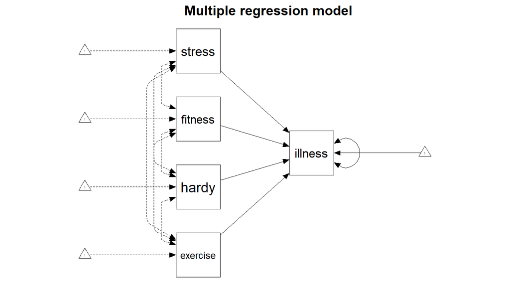

## Regressão múltipla no lavaan (Avaliação)

```r
summary(fit.2, standardized = TRUE, rsquare = TRUE)
```

```r
parameterEstimates(fit.2, rsquare = TRUE)[parameterEstimates(fit.2)$op=="~",]
```

```
##        lhs op      rhs    est    se      z pvalue ci.lower ci.upper
## 1  illness  ~ exercise  0.032 0.048  0.664  0.507   -0.062    0.126
## 2  illness  ~    hardy -0.121 0.079 -1.532  0.126   -0.277    0.034
## 3  illness  ~  fitness -0.442 0.087 -5.074  0.000   -0.612   -0.271
## 4  illness  ~   stress  0.271 0.045  6.008  0.000    0.183    0.360
## 21 illness r2  illness  0.183    NA     NA     NA       NA       NA
```

- **Concluímos que os efeitos de *Exercise* (*p* = .507) e *hardy* (*p* = .126) deixam ser significativos, quando *fitness* e *stress* são também incluídos no modelo. No entanto, *fitness* e *stress* predizem significativamente *illness*.**
  - Ex., ao aumento em *fitness* de 1 ponto está associado um decréscimo médio de quase meio ponto (*b* = -.44) de *illness*.
- O \(R^{2}\) indica que o modelo explica quase 20% da variância de *illnesse* (\(R^{2} = .18\))

## Modelos de Mediação

De seguida, reproduzimos o modelo de mediação apresentado por Rex Kline em *Principles and Practice of SEM* (3ª ed.), figure 8.1.

No modelo de regressão múltipla anterior, *fitness* e *stress* estavam especificados unicamente como variáveis independentes

No modelo seguinte *fitness* e *stress* assumem o papel de variáveis mediadoras

- **São especificados os seguintes efeitos:**
  - os efeitos diretos de *hardy* e *exercise* nas variáveis *Stress* e *fitness*, respectivamente;
  - os efeitos indiretos de *hardy* e *exercise* sobre *illness* via *stress* e *fitness*, respetivamente.

## Modelos de Mediação (Especificação)

[interactive chart not shown]

## Modelos de Mediação (Estimação)

Este modelo é transmitido ao lavaan através da seguinte fórmula

```r
model.3 <- "
# regressões
fitness ~ exercise
stress ~ hardy
illness ~ fitness + stress
"
fit.3 <- sem(model.3, data=DF_roth, meanstructure=T)
fit.3
```

```
## lavaan 0.6-9 ended normally after 25 iterations
##
##   Estimator                                         ML
##   Optimization method                           NLMINB
##   Number of model parameters                        10
##
##   Number of observations                           373
##
## Model Test User Model:
##
##   Test statistic                                11.107
##   Degrees of freedom                                 5
##   P-value (Chi-square)                           0.049
```

## Modelos de Mediação (Avaliação)

Os resultados são obtidos com recurso às funções **summary()** e **parameterestimates()**

```r
summary(fit.3, fit.measures = TRUE, standardized = TRUE, rsquare = TRUE)
```

```r
parameterestimates(fit.3)[parameterEstimates(fit.3)$op=="~",]
```

```
##       lhs op      rhs    est    se      z pvalue ci.lower ci.upper
## 1 fitness  ~ exercise  0.216 0.026  8.180      0    0.164    0.268
## 2  stress  ~    hardy -0.406 0.089 -4.564      0   -0.580   -0.231
## 3 illness  ~  fitness -0.424 0.080 -5.323      0   -0.581   -0.268
## 4 illness  ~   stress  0.287 0.044  6.546      0    0.201    0.373
```

## Algumas Notas Sobre a Avaliação do Modelo

- Identificação do modelo
  - Um modelo é identificado quando existe suficiente informação para estimar os parâmetros especificados
  - Um das regras para percebermos se está identificado é a regra t

> *devem existir mais médias, variâncias e covariâncias observadas do que parâmetros a estimar*
- para **p** variáveis endógenas e **q** variáveis exogenas a seguinte fórmula dá o **k** número de médias, variâncias e covariâncias

\[\small k=\frac{(p+q)(p+q+1)}{2}+(p+q)\]

## Algumas Notas Sobre a Avaliação do Modelo

- Para **t** parâmetros livres (a estimar) a regra t estabelece que:
  - Para o modelo ser identificado, **t** deve ser inferior ou igual a **k**.

> se **t** < **k**: modelo sobre-identificado  
> se **t** = **k**: modelo satura  
> se **t** > **k**: modelo sub-identificado

*A regra t é uma condição necessária mas não suficiente para definir se um modelo é identificado*

**Nota.** \(k-t\) representa os DF para o teste \(\chi^2\) do ajustamento global do modelo

## Algumas Notas Sobre a Avaliação do Modelo

- Pelo diagrama, o modelo estima 15 parâmetros (\(t=15\)).

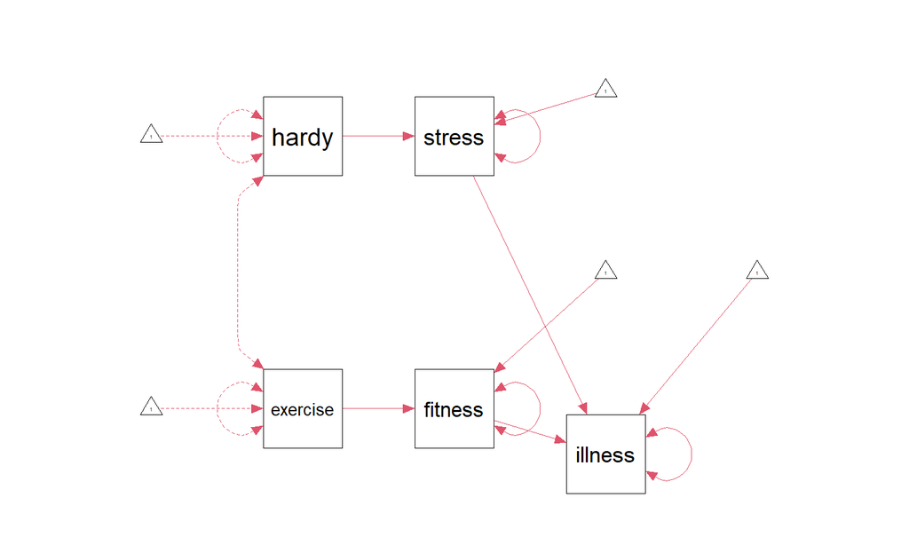

- Pela fórmula anterior, as matrizes observadas somam 20 elementos \[\tiny k=\frac{(3+2)(3+2+1)}{2}+(3+2)=20\]

**Assim, o modelo é identificado com 5 graus de liberdade** (\(k-t\)=5)

## Algumas Notas Sobre a Avaliação do Modelo

Para além do sumário do modelo, o lavaan permite inspecionar/extrair informação interna ao processo de estimação do modelo

- Start values usados na estimação ML

```r
lavInspect(fit.1, what = "start") # Starting values for all model parameters
```

- Parâmetros estimados pelo modelo

```r
lavInspect(fit.3, what = "npar")
lavInspect(fit.3, what = "free") # The non-zero integers represent the free parameters
lavInspect(fit.3, what = "parTable") # All entries (fixed or free) in the parameter table
```

- Estimativas para os parâmetros

```r
lavInspect(fit.3, what = "est")
```

## Modelos de Mediação (Avaliação)

A sobre-identificação do modelo permite avaliar o seu ajustamento aos dados  
- Esta avaliação pode ser feita pela análise dos resíduos do modelo.

```r
lavInspect(fit.3, what = "implied") # model-implied summary statistics
lavInspect(fit.3, what = "sampstat") # Sample statistic
lavInspect(fit.3, what = "resid") # difference between observed and model-implied summary statistics
```

Os resíduos normalizados não devem estar fora do intervalo [-.1; .1] (Kline, 2016)  
- *Valores fora deste intervalo sugerem necessidade de re-especificação*

```r
lavResiduals(fit.3, type = "cor.bentler")$cov # resíduo dividido pelo seu desvio padrão
```

```
##          fitnss stress illnss exercs hardy
## fitness   0.000
## stress   -0.133  0.000
## illness  -0.041  0.033  0.020
## exercise  0.000 -0.057  0.015  0.000
## hardy     0.082  0.000 -0.092  0.000  0.000
```

## Modelos de Mediação (Avaliação)

Podemos ainda recorrer a diferentes indicadores de ajustamento  
- A lista completa de indicadores de ajustamento disponíveis é a seguinte:

```r
fitMeasures(fit.3)[1:32]
```

```
##                npar                fmin               chisq                  df
##        1.000000e+01        1.488936e-02        1.110746e+01        5.000000e+00
##              pvalue      baseline.chisq         baseline.df     baseline.pvalue
##        4.929043e-02        1.656080e+02        9.000000e+00        0.000000e+00
##                 cfi                 tli                nnfi                 rfi
##        9.610016e-01        9.298029e-01        9.298029e-01        8.792725e-01
##                 nfi                pnfi                 ifi                 rni
##        9.329292e-01        5.182940e-01        9.619729e-01        9.610016e-01
##                logl   unrestricted.logl                 aic                 bic
##       -5.964539e+03       -5.958985e+03        1.194908e+04        1.198829e+04
##              ntotal                bic2               rmsea      rmsea.ci.lower
##        3.730000e+02        1.195657e+04        5.722569e-02        2.994463e-03
##      rmsea.ci.upper        rmsea.pvalue                 rmr          rmr_nomean
##        1.031330e-01        3.364357e-01        1.160498e+02        1.340027e+02
##                srmr        srmr_bentler srmr_bentler_nomean                crmr
##        4.440663e-02        4.440663e-02        5.127636e-02        5.926300e-02
```

## Índices de Ajustamento

Em psicologia, alguns dos indicadores mais usados são:

```r
fitMeasures(fit.3, c("chisq", "df", "pvalue", "rmsea", "rmsea.ci.lower", "rmsea.ci.upper", "cfi", "tli",  "srmr"))
```

```
##          chisq             df         pvalue          rmsea rmsea.ci.lower
##         11.107          5.000          0.049          0.057          0.003
## rmsea.ci.upper            cfi            tli           srmr
##          0.103          0.961          0.930          0.044
```

Existem diferentes guidelines para interpretar os vários indicadores. Uma síntese pode ser encontrada [**aqui**](http://www.davidakenny.net/cm/fit.htm#:~:text=Fit%20refers%20to%20the%20ability,does%20not%20necessarily%20require%20respecification.).

Uma discussão mais aprofundada acerca dos diferentes indicadores de ajustamento poderá ser lida neste [**link**](http://web.pdx.edu/~newsomj/semclass/ho_fit.pdf) .

## Índices de Ajustamento

- Não existe uma abordagem universalmente aceite para avaliar o ajustamento em SEM
  - *Não existe um número mágico que defina bom ajustamento*
  - *Não existem regras de ouro para valores de corte de índices de ajustamento*

Recomenda-se uma visão holística do modelo, analizando o ajustamento de diferentes ângulos

## Índices de Ajustamento Absoluto

- Likelihood Ratio Test (teste \(\chi^2\)) - teste mais conhecido e popular

\(H0: \Sigma = \Sigma(\hat{\theta})\), \(\nu = \nu(\hat{\theta})\) Ou \(H0: \Sigma - \Sigma(\hat{\theta})=0\), \(\nu - \nu(\hat{\theta})=0\)

i.e., Os valores de médias, variâncias e covariâncias implícitas ao modelo são iguais aos valores da população (estimados da amostra)

- **Testa-se esta hipótese, comparando o modelo especificado com o modelo saturado**
  - O modelo saturado não impõe qualquer restrição. As estimativas ML deste modelo são \(S\) e \(m\)
  - **Rejeitar H0** (*p*<.05) - modelo testado tem pior ajustamento que o modelo saturado (melhor modelo possível)
  - **Não rejeitar H0** (*p*>.05) - não existem diferenças significativas entre os dois modelos

## Índices de Ajustamento Absoluto

Medida da não centralidade: \(d = \chi^2 - df\)  
- O modelo com ajustamento perfeito é aquele em \(d = 0\)

Root Mean Square Error of Approximation (RMSEA)  
- Tem por base o parâmetro de não centralidade; Distribuíção conhecida (podem ser calculados IC); Valores próximos de 0 indicam bom ajustamento

\[\small RMSEA=\sqrt{\frac{T_h - df_h}{df_h(N-1)}}\] \(T_h\) = Estatistica t para o modelo testados  
\(df_h\) = Graus de liberdade para o modelo testados  
\(N\) = Tamanho da amostra

## Índices de Ajustamento Absoluto

- Standardized Root Mean Square Residual (SRMR)
  - Expressa a diferença normalizada entre \(S\) e \(\Sigma(\hat{\theta})\) (i.e., dados observados e estimativas do modelo)

\[\small SRMR=\sqrt{\sum\sum(r_{ij}-p_{ij})^2}/v\] \(r_{ij}\) = Correlações observadas  
\(p_{ij}\) = Correlações estimadas pelo modelo  
\(v\) = Número de variáveis no modelo

- Não é penalizado pelo número de parâmetros - tende a ser pior em modelos mais complexos e com N menor
- Índice mais descritivo sem uma distribuíção conhecida
- Valores próximos de 0 são indicativos de bom ajustamento

## Índices de Ajustamento Relativo

- Comparam o modelo testado com um outro modelo habitualmente denominado de modelo nulo ou “baseline” (e.g., CFI, TLI, IFI…)
  - O modelo nulo caracteriza-se pela independência das variáveis (pior modelo possível), tendo associado um elevado valor de \(\chi^2\)
- Para calcular índices de ajustamento relativo é geralmente necessário:
  - Estatistica t e df para o modelo testados (\(T_h\) e \(df_h\))
  - Estatistica t e df para o modelo nulo (\(T_b\) e \(df_b\))

\[\small CFI=\frac{(T_b - df_b)-(T_h-df_h)}{T_b-df_b}\] - *Valores próximos de 1 indicam bom ajustamento*

## Modelos de Mediação (Re-especificação)

Frequentemente, é necessário alterar ou re-especificar um modelo original  
- Orientada pela teoria  
- Índices de modificação - quais as consequências de eventuais alterações no ajustamento do modelo?

*NOTA: Estes índices de modificação podem ser solicitados através da função modindices()*

```r
modindices(fit.3, sort.=TRUE, minimum.value=4) # o primeiro argumento é um objeto gerado pelo lavaan, o segundo (sort.) indica que pretendemos uma lista ordenada com base no índice de modificação e o terceiro (minimum.value) permite filtrar a lista com base no valor mínimo
```

```
##        lhs op     rhs    mi    epc sepc.lv sepc.all sepc.nox
## 19 fitness  ~  stress 5.372 -0.061  -0.061   -0.111   -0.111
## 22  stress  ~ fitness 5.110 -0.207  -0.207   -0.114   -0.114
## 20 fitness  ~ illness 4.386 -0.125  -0.125   -0.211   -0.211
```

#### Col. **mi** expressa a melhoria do chi quadrado do modelo em resultado da inclusão do parâmetro no modelo

#### Col. **epc** “expected parameter change” expressa o valor esperado do parâmetro a modificar

## Modelos de Mediação (Re-especificação)

### De seguida re-especificamos do modelo e verificamos ajustamento?

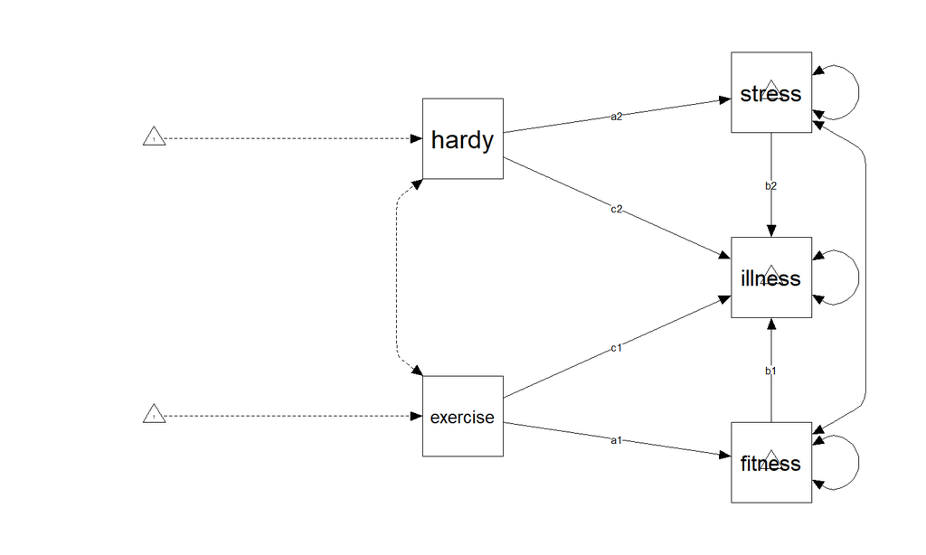

Este modelo acrescenta:  
(1) efeitos diretos de *exercise* e *hardy* sobre *illness*;  
(2) covariância entre *fitness* e *stress*

## Modelos de Mediação (Re-especificação)

O modelo anterior traduz-se na seguinte fórmula no lavaan:

```r
model.4 <- "
# regressões
fitness ~ a1*exercise
stress ~ a2*hardy
illness ~ b1*fitness + b2*stress + c1*exercise + c2*hardy

# covariações
fitness ~~ stress

ind1 := a1*b1
total1 := c1 + (a1*b1)

ind2 := a2*b2
total2 := c2 + (a2*b2)
"
```

- Podemos definir os efeitos totais e indiretos recorrendo ao operador *:=*

## Modelos de Mediação (Re-especificação)

Para estimar os intervalos de confiança dos efeitos indiretos utilizamos o bootstraping apenas com 100 amostras.  
- Na prática este número deve ser bastante maior, sendo que o valor definido por defeito no lavaan é de 5000 amostras.

```r
fit.4 <- sem(model.4, data=DF_roth, meanstructure=T, se = "bootstrap", bootstrap = 100)
```

```r
summary(fit.4, fit.measures = TRUE, standardized = TRUE, rsquare = TRUE)
```

## Modelos de Mediação (Re-especificação)

- Os intervalos de confiança para o modelo podem ser pedidos através da função **parameterestimates()**:

```r
parameterestimates(fit.4)[parameterEstimates(fit.4)$op=="~" | parameterEstimates(fit.4)$op==":=",]
```

```
##        lhs op        rhs  label    est    se      z pvalue ci.lower ci.upper
## 1  fitness  ~   exercise     a1  0.213 0.029  7.260  0.000    0.157    0.274
## 2   stress  ~      hardy     a2 -0.390 0.093 -4.170  0.000   -0.563   -0.200
## 3  illness  ~    fitness     b1 -0.442 0.080 -5.509  0.000   -0.595   -0.268
## 4  illness  ~     stress     b2  0.271 0.041  6.541  0.000    0.198    0.362
## 5  illness  ~   exercise     c1  0.032 0.050  0.634  0.526   -0.080    0.124
## 6  illness  ~      hardy     c2 -0.121 0.074 -1.651  0.099   -0.271    0.043
## 19    ind1 :=      a1*b1   ind1 -0.094 0.020 -4.586  0.000   -0.144   -0.060
## 20  total1 := c1+(a1*b1) total1 -0.062 0.051 -1.213  0.225   -0.182    0.032
## 21    ind2 :=      a2*b2   ind2 -0.106 0.031 -3.370  0.001   -0.180   -0.062
## 22  total2 := c2+(a2*b2) total2 -0.227 0.075 -3.030  0.002   -0.413   -0.069
```

```r
# se necessário intervalos de confiança
```

## Modelos de Mediação (Re-especificação)

Finalmente, recorremos ao Likelihood Ratio Test (LRT) para comparar modelos  
- Este teste determina se os modelos apresentam diferenças significativas no seu ajustamento aos dados

```r
anova(fit.3, fit.4)
```

```
## Chi-Squared Difference Test
##
##       Df   AIC   BIC  Chisq Chisq diff Df diff Pr(>Chisq)
## fit.4  2 11948 11999  4.217
## fit.3  5 11949 11988 11.107     6.8905       3    0.07547 .
## ---
## Signif. codes:  0 '***' 0.001 '**' 0.01 '*' 0.05 '.' 0.1 ' ' 1
```

```r
# OU
lavTestLRT(fit.3, fit.4)
```

*p* > .05 logo não podemos rejeitar a hipótese nula de que os ajustamentos dos modelos são iguais (i.e.,); os dois modelos não apresentam diferenças significativas no seu ajustamento

## Modelos de Mediação (Re-especificação)

Podemos comparar indicadores de ajustamento com a função **compareFit()**

```r
summary(compareFit(fit.3, fit.4, nested = TRUE))
```

```
## ################### Nested Model Comparison #########################
## Chi-Squared Difference Test
##
##       Df   AIC   BIC  Chisq Chisq diff Df diff Pr(>Chisq)
## fit.4  2 11948 11999  4.217
## fit.3  5 11949 11988 11.107     6.8905       3    0.07547 .
## ---
## Signif. codes:  0 '***' 0.001 '**' 0.01 '*' 0.05 '.' 0.1 ' ' 1
##
## ####################### Model Fit Indices ###########################
##         chisq df pvalue rmsea   cfi   tli  srmr        aic        bic
## fit.4  4.217†  2   .121 .055† .986† .936† .025† 11948.187† 11999.167
## fit.3 11.107   5   .049 .057  .961  .930  .044  11949.077  11988.293†
##
## ################## Differences in Fit Indices #######################
##               df rmsea    cfi    tli  srmr  aic     bic
## fit.3 - fit.4  3 0.003 -0.025 -0.006 0.019 0.89 -10.874
```